# Investigation of differential gene expression based on gender in muscle tissue

2022-05-09

## Introduction

In this project, we want to investigate whether or not there is a difference in gene expression between male and female muscle tissue. We will carry out the investigation based on data from the Genotype-Tissue Expression (GTEx) data base, which holds samples from deceased individuals who donated their bodies to science.

We will focus on the expression of 20,000 genes. The individuals in the data set have died of various reasons (natural or illness-related) and their age span from 20 to 79 years old.

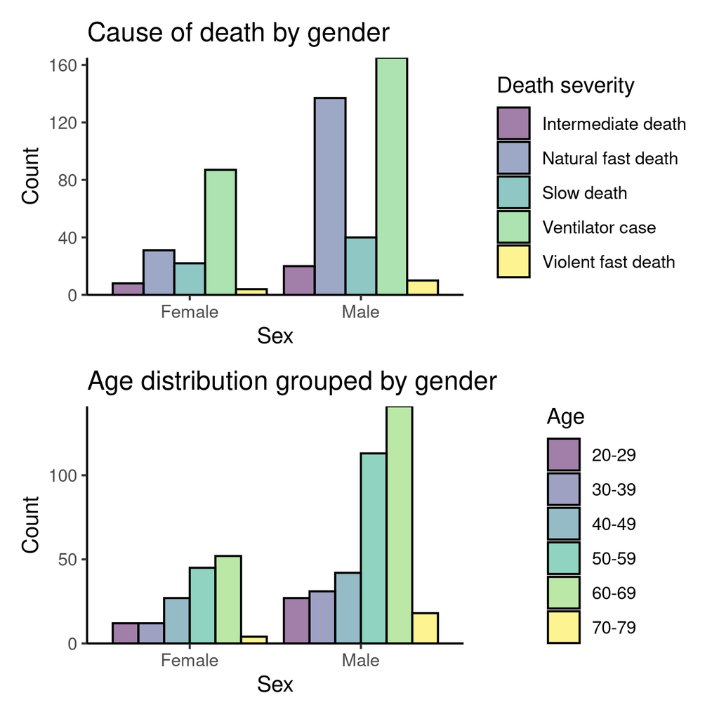

## Material and Methods: Data files and analyses

**File descriptions**

- Three files from the GTex Portal (open source):
  - Subject phenotype file: contains phenotype attributes of the subjects (Age and gender).
  - Sample attribute file: contains data like sample ID, tissue type or RIN number.
  - Gene counts file: Each row is a gene, each column is a sample from a patient. The cell value is the gene expression.

**Description of analyses**

- Principal Component Analysis: reduce data dimension from 20,000 to 2. Look for initial signs of data clustering.
- DESeq2: Calculate the log2fold change in gene expression between classes. In our case, between male and female muscle tissue gene expression.

## Material and Methods - Cleaning the data

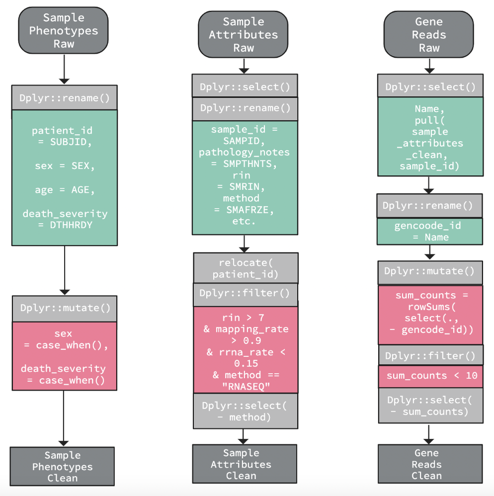

## Material and Methods - Augmentation

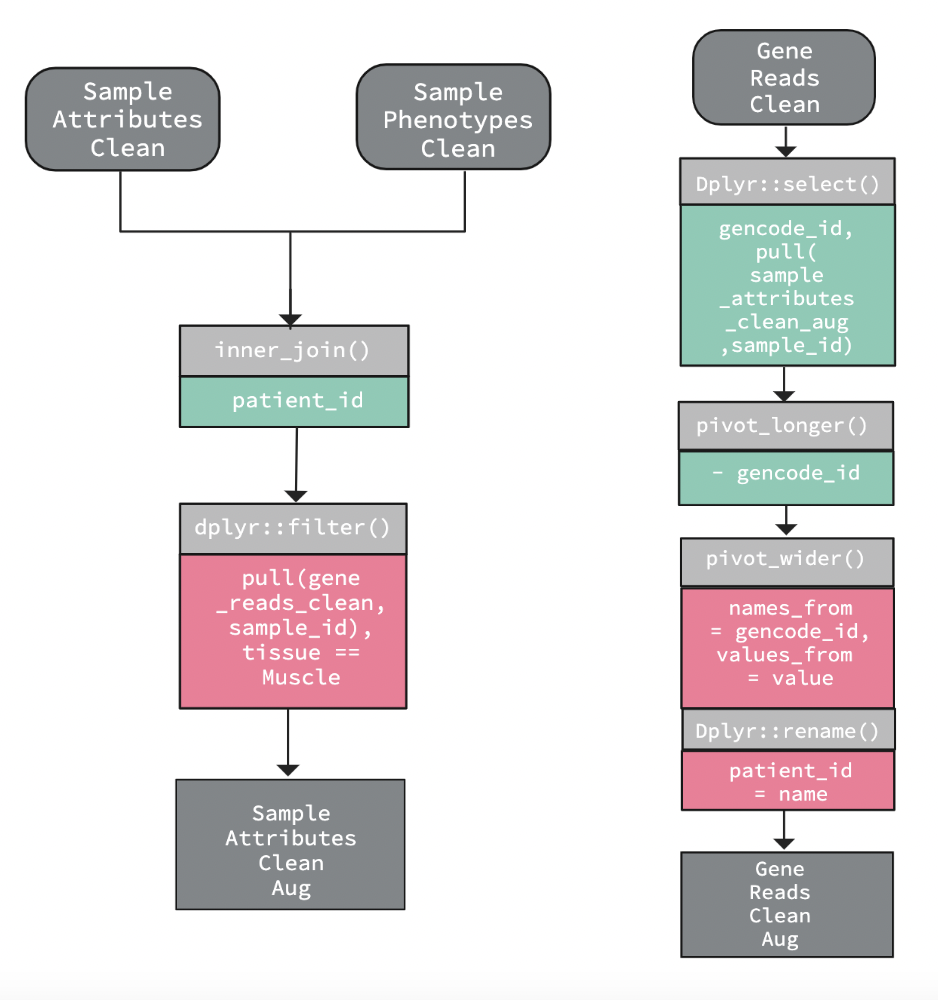

## Challenges

- Tidy data, with observations (patients) as rows and variables (genes) as columns, had to be trasnposed for the DESeq2 analysis.

## Results - Volcano Plot

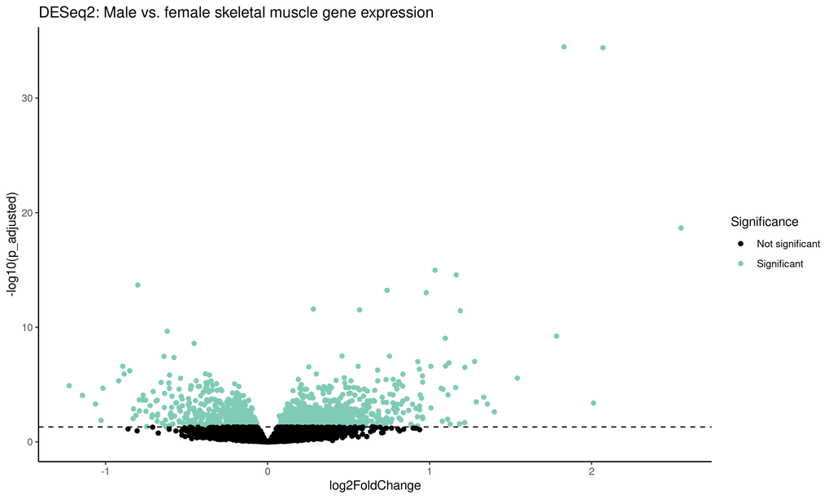

## Discussion

All in all, we have seen indications that there is a difference in gene expression in muscle tissue in men and women.

There was a lack of a control group in the data.